# Objetos en R

### Tipo 5: `vector` — múltiples valores del mismo tipo

Un vector guarda varios valores en una sola variable con `c()` (*combine*). Todos los elementos deben ser del mismo tipo.

```r
# Vector de caracteres
palabras <- c("Me", "gusta", "mi", "clase", "de", "R")
str(palabras)       # chr [1:6]
```

```
#>  chr [1:6] "Me" "gusta" "mi" "clase" "de" "R"
```

```r
length(palabras)    # 6 elementos
```

```
#> [1] 6
```

```r
# Vector numérico
calificaciones <- c(78, 85, 92, 67, 90, 88)
mean(calificaciones)  # Promedio: 83.3
```

```
#> [1] 83.33333
```

```r
max(calificaciones)   # Máximo:   92
```

```
#> [1] 92
```

```r
min(calificaciones)   # Mínimo:   67
```

```
#> [1] 67
```

```r
range(calificaciones) # Rango:    67 92
```

```
#> [1] 67 92
```

#### Acceder a elementos por posición

> **Importante:** en R los índices empiezan en **1**, no en 0 como en Python.

```r
calificaciones[1]    # Primer elemento:  78
```

```
#> [1] 78
```

```r
calificaciones[3]    # Tercer elemento:  92
```

```
#> [1] 92
```

```r
calificaciones[2:4]  # Del segundo al cuarto: 85 92 67
```

```
#> [1] 85 92 67
```

#### Secuencias rápidas con `:`

```r
dias <- 1L:7L
str(dias)    # int [1:7] 1 2 3 4 5 6 7
```

```
#>  int [1:7] 1 2 3 4 5 6 7
```

```r
print(dias)
```

```
#> [1] 1 2 3 4 5 6 7
```

### Tipo 6: `factor` — variable categórica

Un factor es como un `character` pero con categorías fijas llamadas **levels**. Es ideal para variables como nivel educativo, región, género o carrera.

```r
nivel_edu <- factor(c("Licenciatura", "Maestria", "Doctorado",
                      "Licenciatura", "Maestria", "Maestria"))
print(nivel_edu)
```

```
#> [1] Licenciatura Maestria     Doctorado    Licenciatura Maestria
#> [6] Maestria
#> Levels: Doctorado Licenciatura Maestria
```

```r
levels(nivel_edu)   # Categorías disponibles
```

```
#> [1] "Doctorado"    "Licenciatura" "Maestria"
```

```r
table(nivel_edu)    # Frecuencia de cada categoría
```

```
#> nivel_edu
#>    Doctorado Licenciatura     Maestria
#>            1            2            3
```

#### Factor ordenado (variable ordinal)

Cuando las categorías tienen jerarquía, usamos `ordered = TRUE`:

```r
satisfaccion <- factor(
  c("Alto", "Medio", "Bajo", "Alto", "Bajo"),
  levels  = c("Bajo", "Medio", "Alto"),
  ordered = TRUE
)
print(satisfaccion)
```

```
#> [1] Alto  Medio Bajo  Alto  Bajo
#> Levels: Bajo < Medio < Alto
```

```r
satisfaccion[1] > satisfaccion[3]   # ¿Alto > Bajo? -> TRUE
```

```
#> [1] TRUE
```

### Tipo 7: `data.frame` — tabla de datos

El objeto más usado en análisis de datos. Piénsalo como una hoja de Excel: **filas = observaciones**, **columnas = variables**. Cada columna puede ser de un tipo diferente.

```r
estudiantes <- data.frame(
  nombre       = c("Ana", "Luis", "Maria", "Carlos", "Sofia", "Pedro"),
  edad         = c(22L, 25L, 21L, 23L, 20L, 24L),
  calificacion = c(90.5, 58.0, 95.3, 82.1, 47.6, 76.4),
  carrera      = factor(c("Economia", "Derecho", "Economia",
                          "Derecho", "Economia", "Derecho")),
  aprobado     = c(TRUE, FALSE, TRUE, TRUE, FALSE, TRUE)
)

print(estudiantes)
```

```
#>   nombre edad calificacion  carrera aprobado
#> 1    Ana   22         90.5 Economia     TRUE
#> 2   Luis   25         58.0  Derecho    FALSE
#> 3  Maria   21         95.3 Economia     TRUE
#> 4 Carlos   23         82.1  Derecho     TRUE
#> 5  Sofia   20         47.6 Economia    FALSE
#> 6  Pedro   24         76.4  Derecho     TRUE
```

#### Explorar la estructura

```r
str(estudiantes)       # Tipo de cada columna
```

```
#> 'data.frame':    6 obs. of  5 variables:
#>  $ nombre      : chr  "Ana" "Luis" "Maria" "Carlos" ...
#>  $ edad        : int  22 25 21 23 20 24
#>  $ calificacion: num  90.5 58 95.3 82.1 47.6 76.4
#>  $ carrera     : Factor w/ 2 levels "Derecho","Economia": 2 1 2 1 2 1
#>  $ aprobado    : logi  TRUE FALSE TRUE TRUE FALSE TRUE
```

```r
nrow(estudiantes)      # Número de filas
```

```
#> [1] 6
```

```r
ncol(estudiantes)      # Número de columnas
```

```
#> [1] 5
```

```r
dim(estudiantes)       # Dimensiones: 6 x 5
```

```
#> [1] 6 5
```

```r
summary(estudiantes)   # Resumen estadístico
```

```
#>     nombre               edad        calificacion       carrera
#>  Length:6           Min.   :20.00   Min.   :47.60   Derecho :3
#>  Class :character   1st Qu.:21.25   1st Qu.:62.60   Economia:3
#>  Mode  :character   Median :22.50   Median :79.25
#>                     Mean   :22.50   Mean   :74.98
#>                     3rd Qu.:23.75   3rd Qu.:88.40
#>                     Max.   :25.00   Max.   :95.30
#>   aprobado
#>  Mode :logical
#>  FALSE:2
#>  TRUE :4
#>
#>
#>
```

#### Acceder a columnas con `$`

```r
estudiantes$nombre
```

```
#> [1] "Ana"    "Luis"   "Maria"  "Carlos" "Sofia"  "Pedro"
```

```r
estudiantes$calificacion
```

```
#> [1] 90.5 58.0 95.3 82.1 47.6 76.4
```

```r
mean(estudiantes$calificacion)  # Promedio general
```

```
#> [1] 74.98333
```

```r
max(estudiantes$calificacion)   # Calificación más alta
```

```
#> [1] 95.3
```

#### Filtrar filas

```r
# Solo estudiantes aprobados
estudiantes[estudiantes$aprobado == TRUE, ]
```

|  | nombre | edad | calificacion | carrera | aprobado |
| --- | --- | --- | --- | --- | --- |
| 1 | Ana | 22 | 90.5 | Economia | TRUE |
| 3 | Maria | 21 | 95.3 | Economia | TRUE |
| 4 | Carlos | 23 | 82.1 | Derecho | TRUE |
| 6 | Pedro | 24 | 76.4 | Derecho | TRUE |

```r
# Solo estudiantes de Economía
estudiantes[estudiantes$carrera == "Economia", ]
```

|  | nombre | edad | calificacion | carrera | aprobado |
| --- | --- | --- | --- | --- | --- |
| 1 | Ana | 22 | 90.5 | Economia | TRUE |
| 3 | Maria | 21 | 95.3 | Economia | TRUE |
| 5 | Sofia | 20 | 47.6 | Economia | FALSE |

#### Agregar una nueva columna

```r
estudiantes$beca <- estudiantes$calificacion >= 85
print(estudiantes)
```

```
#>   nombre edad calificacion  carrera aprobado  beca
#> 1    Ana   22         90.5 Economia     TRUE  TRUE
#> 2   Luis   25         58.0  Derecho    FALSE FALSE
#> 3  Maria   21         95.3 Economia     TRUE  TRUE
#> 4 Carlos   23         82.1  Derecho     TRUE FALSE
#> 5  Sofia   20         47.6 Economia    FALSE FALSE
#> 6  Pedro   24         76.4  Derecho     TRUE FALSE
```

## Parte 3 — Errores comunes y cómo evitarlos

Estos son los errores que casi todos los principiantes cometen. Léelos con atención para ahorrar tiempo y frustración.

### Error 1: Olvidar las comillas en un `character`

```r
# ✗ R buscará un objeto llamado "hola" y dará error:
texto <- hola

# ✓ correcto:
texto <- "hola"
```

### Error 2: Confundir `==` (comparar) con `=` (asignar)

```r
x <- 10

# ✗ esto intenta asignar, no comparar:
if (x = 5) { ... }

# ✓ correcto:
if (x == 5) { ... }
```

### Error 3: Usar `c` como nombre de objeto

```r
# ✗ peligroso — "c" también es el nombre de la función c():
c <- 10
c(1, 2, 3)   # ahora "c" es 10, no la función → ERROR

# ✓ usa nombres descriptivos:
conteo <- 10
```

### Error 4: Índices fuera de rango

```r
# calificaciones tiene 6 elementos (índices del 1 al 6)
calificaciones[10]   # devuelve NA — bug silencioso

# ✓ siempre verifica con length() antes de indexar:
length(calificaciones)   # 6 → máximo índice permitido es 6
```

### Error 5: Mayúsculas y minúsculas importan

```r
Nombre <- "Ana"
print(nombre)   # Error: object 'nombre' not found
                # "Nombre" y "nombre" son dos objetos distintos
```

### Error 6: Usar `=` en vez de `<-` para asignar *(estilo)*

```r
# Funciona, pero no es la convención en R:
x = 5

# ✓ convención estándar de la comunidad R:
x <- 5
```

## Parte 4 — El loop `for`

Un `for` repite el mismo bloque de código para cada elemento de una secuencia. Evita copiar y pegar el mismo código muchas veces.

**Estructura:**

```r
for (variable_temporal in secuencia) {
    código que se repite en cada vuelta
}
```

### Ejemplo 1: números del 1 al 5

```r
for (i in 1:5) {
  cat("Vuelta número:", i, "\n")
}
```

```
#> Vuelta número: 1
#> Vuelta número: 2
#> Vuelta número: 3
#> Vuelta número: 4
#> Vuelta número: 5
```

### Ejemplo 2: recorrer un vector de nombres

```r
personas <- c("Ana", "Luis", "Maria", "Pedro", "Sandra")

for (persona in personas) {
  cat("Hola,", persona, "! Bienvenid@ a la clase de R.\n")
}
```

```
#> Hola, Ana ! Bienvenid@ a la clase de R.
#> Hola, Luis ! Bienvenid@ a la clase de R.
#> Hola, Maria ! Bienvenid@ a la clase de R.
#> Hola, Pedro ! Bienvenid@ a la clase de R.
#> Hola, Sandra ! Bienvenid@ a la clase de R.
```

### Ejemplo 3: acceder a dos vectores al mismo tiempo con índice

```r
asignaturas <- c("Estadística", "Programación", "Bases de Datos")
notas       <- c(9.5, 8.0, 9.0)

for (i in 1:length(asignaturas)) {
  cat(asignaturas[i], "->", notas[i], "\n")
}
```

```
#> Estadística -> 9.5
#> Programación -> 8
#> Bases de Datos -> 9
```

### Ejemplo 4: `for` + `if/else`

```r
for (i in 1:length(asignaturas)) {
  if (notas[i] >= 9) {
    cat(asignaturas[i], ": EXCELENTE (", notas[i], ")\n")
  } else {
    cat(asignaturas[i], ": BUENO     (", notas[i], ")\n")
  }
}
```

```
#> Estadística : EXCELENTE ( 9.5 )
#> Programación : BUENO     ( 8 )
#> Bases de Datos : EXCELENTE ( 9 )
```

## Parte 5 — Ejercicio 1: tipos de objetos y `paste0()`

**Instrucciones:**

Crea 5 objetos con nombres descriptivos:

- `frase_base`: un `character` con el texto `"Me gusta correr"`
- `km_mes`: un `integer` con el valor `100`
- `horas_dia`: un `numeric` con el valor `1.5`
- `horas_dos_dias`: la suma de `horas_dia + horas_dia`
- `oracion`: una oración con sentido usando `paste0()` y los 4 objetos anteriores

Imprime `oracion` y verifica el tipo de cada objeto con `class()`.

> **Intenta resolverlo antes de ver la solución.**

```r
# --- TU CÓDIGO AQUÍ ---
```

**Ver solución**

```r
frase_base     <- "Me gusta correr"   # character
km_mes         <- 100L                # integer
horas_dia      <- 1.5                 # numeric
horas_dos_dias <- horas_dia + horas_dia  # numeric: 1.5 + 1.5 = 3

oracion <- paste0(
  frase_base, " ", km_mes,
  " km al mes; en promedio corro ", horas_dia,
  " horas al dia, es decir, ", horas_dos_dias,
  " horas cada 2 dias."
)

print(oracion)
```

```
#> [1] "Me gusta correr 100 km al mes; en promedio corro 1.5 horas al dia, es decir, 3 horas cada 2 dias."
```

```r
cat("\nTipos de los objetos:\n")
```

```
#>
#> Tipos de los objetos:
```

```r
cat("frase_base    :", class(frase_base),     "\n")
```

```
#> frase_base    : character
```

```r
cat("km_mes        :", class(km_mes),         "\n")
```

```
#> km_mes        : integer
```

```r
cat("horas_dia     :", class(horas_dia),      "\n")
```

```
#> horas_dia     : numeric
```

```r
cat("horas_dos_dias:", class(horas_dos_dias), "\n")
```

```
#> horas_dos_dias: numeric
```

```r
cat("oracion       :", class(oracion),        "\n")
```

```
#> oracion       : character
```

## Parte 6 — Ejercicio 2: vectores y estadísticas

**Instrucciones:**

> **Pista:** para generar una secuencia rápida usa `:` (ej. `1:10`)

```r
# --- TU CÓDIGO AQUÍ ---
```

**Ver solución**

```r
vec_pares   <- c(2, 4, 6, 8, 10)   # números pares del 1 al 10
vec_enteros <- 1:100                # enteros del 1 al 100

media_pares   <- mean(vec_pares)
suma_pares    <- sum(vec_pares)
media_enteros <- mean(vec_enteros)
suma_enteros  <- sum(vec_enteros)

cat("vec_pares   -> Media:", media_pares,   "| Suma:", suma_pares,   "\n")
```

```
#> vec_pares   -> Media: 6 | Suma: 30
```

```r
cat("vec_enteros -> Media:", media_enteros, "| Suma:", suma_enteros, "\n")
```

```
#> vec_enteros -> Media: 50.5 | Suma: 5050
```

```r
resultado1 <- suma_pares   * media_pares      # Suma × Media de vec_pares
resultado2 <- suma_enteros - media_enteros    # Suma − Media de vec_enteros
resultado3 <- suma_enteros / suma_pares       # Suma enteros / Suma pares

cat("\nOperaciones:\n")
```

```
#>
#> Operaciones:
```

```r
cat("suma_pares × media_pares      :", resultado1, "\n")
```

```
#> suma_pares × media_pares      : 180
```

```r
cat("suma_enteros − media_enteros  :", resultado2, "\n")
```

```
#> suma_enteros − media_enteros  : 4999.5
```

```r
cat("suma_enteros / suma_pares     :", resultado3, "\n")
```

```
#> suma_enteros / suma_pares     : 168.3333
```

### Visualización rápida

Con R Markdown podemos mostrar gráficas directamente en el documento, sin necesidad de guardar archivos PNG por separado.

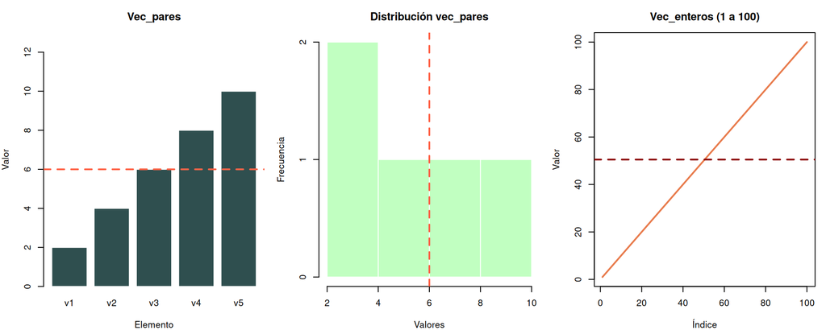

```r
vec_pares   <- c(2, 4, 6, 8, 10)
vec_enteros <- 1:100
media_pares   <- mean(vec_pares)
media_enteros <- mean(vec_enteros)

par(mfrow = c(1, 3), mar = c(4, 4, 3, 1))

# Barras de vec_pares
barplot(vec_pares,
        names.arg = paste0("v", 1:5),
        col = "darkslategray", border = "white",
        main = "Vec_pares",
        xlab = "Elemento", ylab = "Valor", ylim = c(0, 13))
abline(h = media_pares, col = "tomato", lwd = 2, lty = 2)

# Histograma de vec_pares
hist(vec_pares, col = "#C1FFC1", border = "white",
     main = "Distribución vec_pares",
     xlab = "Valores", ylab = "Frecuencia", breaks = 5)
abline(v = media_pares, col = "tomato", lwd = 2, lty = 2)

# Línea de vec_enteros
plot(vec_enteros, type = "l", col = "#E87B4C", lwd = 2,
     main = "Vec_enteros (1 a 100)",
     xlab = "Índice", ylab = "Valor")
abline(h = media_enteros, col = "darkred", lwd = 2, lty = 2)
```

```r
par(mfrow = c(1, 1))
```

## Parte 7 — Ejercicio 3: escribe tu propio `for`

**Instrucciones:**

Tienes las calificaciones de 5 estudiantes. Escribe un `for` que recorra la lista e imprima para cada uno:

- Si `calificacion >= 60`: `"Nombre obtuvo X -> APROBADO"`
- Si `calificacion < 60`: `"Nombre obtuvo X -> REPROBADO"`

**Datos:**

```r
nombres_est <- c("Ana", "Juan", "Maria", "Pedro", "Sofia")
califs      <- c(85, 45, 92, 58, 76)
```

**Estructura de ayuda:**

```r
for (i in 1:length(nombres_est)) {
  if (califs[i] >= 60) {
    cat(...)   # APROBADO
  } else {
    cat(...)   # REPROBADO
  }
}
```

```r
# --- TU CÓDIGO AQUÍ ---
```

**Ver solución**

```r
for (i in 1:length(nombres_est)) {
  if (califs[i] >= 60) {
    cat(nombres_est[i], "obtuvo", califs[i], "-> APROBADO\n")
  } else {
    cat(nombres_est[i], "obtuvo", califs[i], "-> REPROBADO\n")
  }
}
```

```
#> Ana obtuvo 85 -> APROBADO
#> Juan obtuvo 45 -> REPROBADO
#> Maria obtuvo 92 -> APROBADO
#> Pedro obtuvo 58 -> REPROBADO
#> Sofia obtuvo 76 -> APROBADO
```

## Parte 8 — Proyecto integrador

Pon en práctica todo lo aprendido: tipos de objetos, `data.frame`, estadísticas, `for` y gráficas.

**Contexto:** eres el coordinador académico de una carrera con 8 estudiantes. Tienes sus datos del semestre y necesitas generar un reporte completo.

### Paso 1: Crear el `data.frame`

```r
grupo <- data.frame(
  nombre       = c("Ana", "Luis", "Maria", "Carlos",
                   "Sofia", "Pedro", "Elena", "Jorge"),
  edad         = c(22L, 25L, 21L, 23L, 20L, 24L, 22L, 21L),
  calificacion = c(90.5, 58.0, 95.3, 82.1, 47.6, 76.4, 88.0, 63.5),
  carrera      = factor(c("Economia", "Derecho", "Economia", "Derecho",
                          "Economia", "Derecho", "Economia", "Derecho")),
  semestre     = c(4L, 6L, 2L, 8L, 2L, 4L, 6L, 8L)
)

print(grupo)
```

```
#>   nombre edad calificacion  carrera semestre
#> 1    Ana   22         90.5 Economia        4
#> 2   Luis   25         58.0  Derecho        6
#> 3  Maria   21         95.3 Economia        2
#> 4 Carlos   23         82.1  Derecho        8
#> 5  Sofia   20         47.6 Economia        2
#> 6  Pedro   24         76.4  Derecho        4
#> 7  Elena   22         88.0 Economia        6
#> 8  Jorge   21         63.5  Derecho        8
```

### Paso 2: Estadísticas del grupo

```r
promedio_grupo <- mean(grupo$calificacion)
mejor_nota     <- max(grupo$calificacion)
peor_nota      <- min(grupo$calificacion)
num_aprobados  <- sum(grupo$calificacion >= 60)
num_reprobados <- sum(grupo$calificacion <  60)

cat("Promedio del grupo  :", round(promedio_grupo, 2), "\n")
```

```
#> Promedio del grupo  : 75.17
```

```r
cat("Calificación más alta:", mejor_nota, "\n")
```

```
#> Calificación más alta: 95.3
```

```r
cat("Calificación más baja:", peor_nota,  "\n")
```

```
#> Calificación más baja: 47.6
```

```r
cat("Aprobados  :", num_aprobados,  "de", nrow(grupo), "\n")
```

```
#> Aprobados  : 6 de 8
```

```r
cat("Reprobados :", num_reprobados, "de", nrow(grupo), "\n")
```

```
#> Reprobados : 2 de 8
```

### Paso 3: Reporte individual con `for`

```r
cat("====== Reporte individual ======\n")
```

```
#> ====== Reporte individual ======
```

```r
for (i in 1:nrow(grupo)) {

  nom <- grupo$nombre[i]
  cal <- grupo$calificacion[i]
  car <- as.character(grupo$carrera[i])
  sem <- grupo$semestre[i]

  estado  <- if (cal >= 60) "APROBADO" else "REPROBADO"
  mencion <- if (cal >= 90) "** Mención Honorífica **" else ""

  cat(nom, "|", car, "| Semestre", sem,
      "| Calificación:", cal, "|", estado, mencion, "\n")
}
```

```
#> Ana | Economia | Semestre 4 | Calificación: 90.5 | APROBADO ** Mención Honorífica **
#> Luis | Derecho | Semestre 6 | Calificación: 58 | REPROBADO
#> Maria | Economia | Semestre 2 | Calificación: 95.3 | APROBADO ** Mención Honorífica **
#> Carlos | Derecho | Semestre 8 | Calificación: 82.1 | APROBADO
#> Sofia | Economia | Semestre 2 | Calificación: 47.6 | REPROBADO
#> Pedro | Derecho | Semestre 4 | Calificación: 76.4 | APROBADO
#> Elena | Economia | Semestre 6 | Calificación: 88 | APROBADO
#> Jorge | Derecho | Semestre 8 | Calificación: 63.5 | APROBADO
```

### Paso 4: Gráfica de calificaciones

En R Markdown la gráfica aparece directamente en el documento — no necesitamos `png()` ni `dev.off()`.

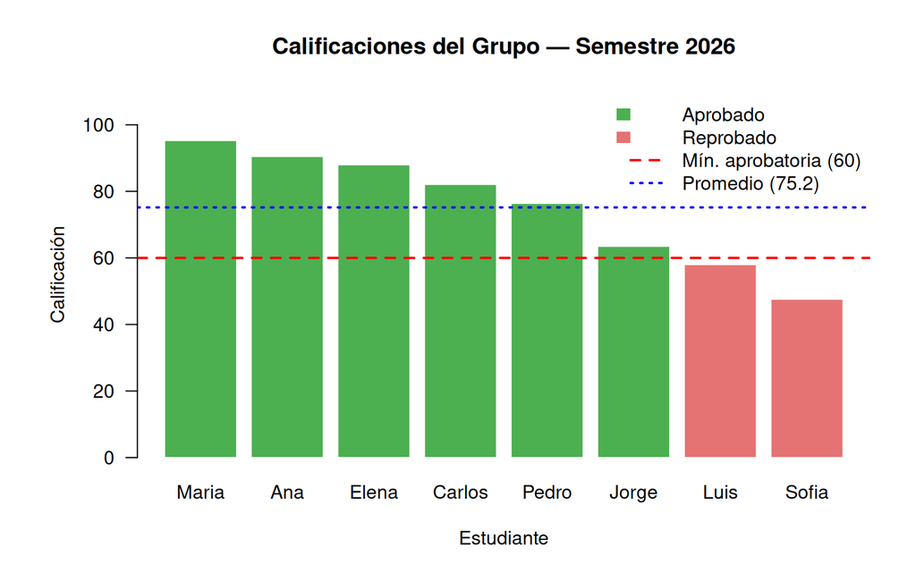

```r
orden   <- order(grupo$calificacion, decreasing = TRUE)
cal_ord <- grupo$calificacion[orden]
nom_ord <- grupo$nombre[orden]
colores <- ifelse(cal_ord >= 60, "#4CAF50", "#E57373")

par(mar = c(5, 6, 4, 2))

barplot(
  cal_ord,
  names.arg = nom_ord,
  col       = colores,
  border    = "white",
  main      = "Calificaciones del Grupo — Semestre 2026",
  xlab      = "Estudiante",
  ylab      = "Calificación",
  ylim      = c(0, 110),
  las       = 1
)

abline(h = 60,             col = "red",  lwd = 2, lty = 2)
abline(h = promedio_grupo, col = "blue", lwd = 2, lty = 3)

legend(
  "topright",
  legend = c("Aprobado", "Reprobado",
             "Mín. aprobatoria (60)",
             paste0("Promedio (", round(promedio_grupo, 1), ")")),
  fill   = c("#4CAF50", "#E57373", NA, NA),
  lty    = c(NA, NA, 2, 3),
  col    = c(NA, NA, "red", "blue"),
  lwd    = c(NA, NA, 2, 2),
  border = NA,
  bty    = "n"
)
```

## Resumen de la clase

| Tipo | Ejemplo | `class()` | Uso típico |
| --- | --- | --- | --- |
| `numeric` | `1.64` | `"numeric"` | Medidas continuas |
| `integer` | `25L` | `"integer"` | Conteos, índices |
| `character` | `"Economía"` | `"character"` | Texto, etiquetas |
| `logical` | `TRUE` | `"logical"` | Condiciones, filtros |
| `vector` | `c(78, 85, 92)` | tipo base | Series de valores del mismo tipo |
| `factor` | `factor(c(...))` | `"factor"` | Variables categóricas |
| `data.frame` | `data.frame(...)` | `"data.frame"` | Tablas de datos (lo más usado) |

## Para la próxima clase

Practica estos conceptos con datos propios:

1. Crea un `data.frame` con información de 5 personas que conozcas (nombre, edad, ciudad, una variable numérica de tu elección)
2. Calcula la media y el máximo de tu variable numérica
3. Usa un `for` para imprimir una oración sobre cada persona